# Getting Data Project

DataTrail Team

# Getting Data

## Project: Leanpub Data

In this project, you will walk through the process of getting data into R so you can begin exploring and analyzing it.

The dataset you created (in Chapter 27 Google Documents in section [27.1.4 Collecting data](https://datatrail-jhu.github.io/DataTrail/google-documents.html#collecting-data)) contains information about books published on Leanpub. It contains information including how many readers they have and the prices suggested by the authors. Once the data is loaded, you will explore its structure, check for any issues, and get it ready for visualizations and statistical analysis. This project is an essential part of learning the data science workflow: from data collection to cleaning, and preparing it for meaningful exploration.

## Objectives for this project

To complete this project, you’ll need to work through a few key steps within this file. As you move through the notebook, you’ll find instructions in each section to help you complete the project step by step.

1. To complete this project, you’ll need to work through a few key steps within this file. As you move through the notebook, you’ll find instructions in each section to help you complete the project step by step.
   1. Before you begin, make sure you’ve completed the steps in the previous chapter and have your Google Sheet with Leanpub data ready to go as it was explained in Chapter 27 Google Documents in section [27.1.4 Collecting data](https://datatrail-jhu.github.io/DataTrail/google-documents.html#collecting-data).
   2. At the very top of this file, put your own name in the `author:` place. Currently it says `"DataTrail Team"`. Be sure to replace it with your name in quotes.
   3. Read through this notebook carefully, following along with each section.
   4. Fill in the empty or incomplete code chunks when prompted.
   5. Run each code chunk as you come across it by clicking the tiny green triangles at the right of each code chunk. You should see the code chunks print out various output when you do this.
   6. In the Conclusions section at the end, write thoughtful responses to each of the questions provided.
   7. When done with this project notebook save the file by going to File > Save in the RStudio menu. This will update the output `.nb.html` file to reflect your changes.
   8. Open your **`leanpub_project.nb.html`** file and click “View in Web Browser”. Check to make sure everything looks good and your changes are showing up as expected.
   9. Upload your Rmd and your nb.html to your assignment folder (this is something that will be dependent on what your instructors have told you – or if you are taking this on your own, just collect these projects in one place, preferably a Google Drive)!

## R Packages

What is an R package was covered in the previous project notebook but you can also revisit [Data Trail Section 22.0.1 What is an R package?](https://datatrail-jhu.github.io/DataTrail/r-packages.html).

In chapter 22 in the section [How do you install packages? (section 22.0.4)](https://datatrail-jhu.github.io/DataTrail/r-packages.html#how-do-you-install-packages) we also learned about installing from CRAN, installing from Bioconductor, and installing from GitHub.

Fortunately the packages you will be using have already been installed! All you need to do is load the packages.

These are the R packages you are going to use:

- [readr](https://readr.tidyverse.org/)
- [googlesheets4](https://googlesheets4.tidyverse.org/)
- [dplyr](https://dplyr.tidyverse.org)
- [ggplot2](https://ggplot2.tidyverse.org/)

## Setting up packages

Before using any package in R, let’s first make sure it’s installed and ready to go!

To check if a package is installed there are a few options:

- Use `installed.packages()`: This shows a list of all packages currently installed.
- Use `library()`: This lists all the packages you can load.
- Check the “Packages” tab in RStudio: It shows a list of installed packages.
  - This tab is usually on the bottom right panel.
  - You can also search for a specific package using the search bar!

To actually use a particular function found within a package, you need to load it using the `library()` function. Loading the package makes its functions available for use in your R session.

You will load the packages using the **`library()`** function including the name of the package in the parenthesis:

```r
library(readr)
library(googlesheets4)
library(dplyr)
```

```r
library(ggplot2)
```

## Setting up directories

Here, you making sure there’s a folder called `"data"` in our project. If it doesn’t already exist, it will be created it using the code below:

```r
if (!dir.exists("data")) {
  dir.create("data")
}
```

#### Breaking it down

- `dir.exists("data")`: This checks whether a folder named `"data"` already exists in your project directory.
- `!dir.exists("data")`: The `!` means “not”, so this condition checks: “Does the folder not exist?”
- `if (...) { ... }`: This is a basic if-statement. It says: If the folder doesn’t exist, then do what’s inside the `{}`.
- `dir.create("data")`: This line creates a new folder named “data”.

## Getting the data

Here you are reading in a Google spreadsheet with information about Leanpub books and their prices. You will read this data in using the [googlesheets4](https://googlesheets4.tidyverse.org/) R package.

First, create an R object with the name `link`. Then assign (`<-`) the URL of your Leanpub GoogleSheet by copying and pasting the URL of your Leanpub from GoogleSheets. Instructions for creating and coping the sharable link can be found in [27.1.4 Collecting data](https://datatrail-jhu.github.io/DataTrail/google-documents.html#collecting-data) section. Make sure to put quotes around the URL.

Next, to read in the data using the code below, you will need to follow the prompt to authorize the data to be read in using your Google login credentials.

*Note: if the console isn’t expanded, you may need to pull up the console sometimes it doesn’t pop up automatically.* *After running the code chunk there will be a question about authorizing access. Select option 1: Yes*

```r
if (interactive()) {
  ## Get data from your Google sheet
  leanpub_df <-  read_sheet(link, col_types = "c")
} else {
  # Or if we already have the sheet but no access to credentials let's read it in from here
  if (file.exists(file.path("data", "leanpub_data.csv"))) {
    leanpub_df <- readr::read_csv(file.path("data", "leanpub_data.csv"))
  }
}
```

#### Breaking it down

- `if (interactive())`:
  - `interactive()`:Checks if you’re in an interactive R session.
  - Returns TRUE if you’re working in something like RStudio or the R console.
  - If TRUE, the block inside runs; otherwise, the else block runs.
- `leanpub_df <- read_sheet(link, col_types = "c") read_sheet()`:
  - `leanpub_df <-`: Creates an object called `leanpub_df` and assigns `<-` output to it.
  - `read_sheet`: This from the googlesheets4 package.
  - `link`: Is expected to be a Google Sheets URL or ID.
  - `col_types = "c"`: Tells the function to read all columns as characters (i.e., “c” = character).
- `} else {`: If the session is not interactive, this block is used.
- `if (file.exists(file.path("data", "leanpub_data.csv"))) {`:
  - Checks if a local CSV file exists at the path “`data/leanpub_data.csv`”.
  - `file.path()`: Is used to construct the path in a platform-independent way.
- `leanpub_df <- readr::read_csv(file.path("data", "leanpub_data.csv"))`:
  - If the file exists, this reads the CSV into the same `leanpub_df` data frame using the readr package.
  - This is a fallback method for loading data when Google Sheets access isn’t available.

### Creating a data file

After successfully creating an R object from googlesheet, let’s save it to a file. This is helpful for sharing your work or picking up right where you left off next time.

Use the `readr::write_csv()` function to save the R data object as a CSV file. Be sure to write it into the `data` directory and name the file: **`"leanpub_data.csv"`**.

*Hint:If you don’t remember how to use the `readr::write_csv()` function, you can look it up using `?readr::write_csv`.* You can also revisit [DataTrail Section 24.0.5: Writing CSV files into Posit Cloud](https://datatrail-jhu.github.io/DataTrail/dataset-file-types.html).

## Exploring the data

Now that you’ve created an R object of your dataset (`leanpub_df`), take a closer look at what kind of data you’re working with!

This step is important because it helps you understand the structure of the data before moving forward with any analysis. Choose one of the basic data exploration functions to investigate the `leanpub_df`.

For instance, you may be interested in the data dimensions.

*Hint: It may be helpful to revisit section [19.0.3 How big is this object?](https://datatrail-jhu.github.io/DataTrail/basic-commands-in-r.html)*

Knowing the structure of the data may also be helpful.

*Hint: It may be helpful to revisit section* [16.0.11 Determining the class and shape of an object](https://datatrail-jhu.github.io/DataTrail/objects-in-r.html).

## Checking the data

Before you move on, you need to make sure your dataset has the right column names in exactly in this order: `title`, `readers`, `suggested`, and `minimum`.

These column names are important because the next steps in our analysis rely on them being named correctly.

Run the following code chunk to check if the column names are correct:

```r
# If all four of our required columns are found, then this will print out TRUE
all(c('title', 'readers', 'suggested', 'minimum') %in% colnames(leanpub_df))
```

```
## [1] TRUE
```

#### Breaking it down

- `all(…)`: all() returns TRUE only if every value in the logical vector is TRUE.
- `c('title', 'readers', 'suggested', 'minimum')`: Creates a character vector of the column names you expect.
- `colnames(leanpub_df)` : Returns a character vector of column names in the data frame leanpub_df.
- `%in% colnames(leanpub_df)`: Checks element-wise whether each of the specified names exists in the data frame’s column names, and Returns a logical vector of true or false for each value.

If it prints **`TRUE`**, great! You’re good to go. If it prints **`FALSE`**, that means one or more of the column names don’t match exactly.

Note: *What to do if it says FALSE: Go back to your Google Sheet, check the column names, and make sure they are spelled exactly like below and that they are in the correct order:*

- `title`
- `readers`
- `suggested`
- `minimum`

*Once they are correct, start from the getting the data section and run each code chunk again.*

## Cleaning the data

You need to make sure that certain columns in your data (such as `readers`, `suggested`, and `minimum`) are being treated as numeric objects (see chapter 16 [section 16.0.6 Numeric](https://datatrail-jhu.github.io/DataTrail/objects-in-r.html)) and not as text.

*Note: Different data types have slightly different behaviors, so knowing their class is useful. You can revisit chapter 16 section [16.0.3.1 Classes of objects](https://datatrail-jhu.github.io/DataTrail/objects-in-r.html) and [16.0.3.2 Why are classes important?](https://datatrail-jhu.github.io/DataTrail/objects-in-r.html) There are five common classes:*

- *Character - e.g. `"sharon""marcus"`*
- *Integer - e.g. `1`, `4` (whole numbers)*
- *Numeric - e.g. `1.2`, `3.4`, `4`*
- *Logical - only two options: `TRUE` or `FALSE`.*
- *Factor - `red`, `red`, `blue`, `yellow` (categories that could be repeated).*

This is important because you will want to do calculate some basic summary statistics with these values, like finding averages and ranges. R can only do this if it knows they are numbers.

```r
leanpub_df <- leanpub_df %>%
  mutate(across(c(readers, suggested, minimum),
                         as.numeric))
```

#### Breaking it down

- `leanpub_df <-`: Will replace the existing `leanpub_df` with the updated version
- `leanpub_df`: The object we will manipulate
- `mutate`: is a dplyr function used to create or modify columns in a data frame
- `across` applies the mutate function to multiple columns, in this case the list (`c`) of `readers`, `suggested`, `and minimum`.
- `as.numeric` converts those columns into number format.

Now that the data are properly being treated as numeric values, you can obtain some summary statistics for your `leanpub_df` dataset. Use a function we have discussed in to do this.

*Hint: You can revisit chapter 19 and scroll to section [19.0.5 What does this object look like?](https://datatrail-jhu.github.io/DataTrail/basic-commands-in-r.html#). As you may recall we covered how the `summary` function computes summary statistics for numeric data. You are trying to get an overview of summary statistics such as the minimum and maximum values, mean (average), median, and more helpful info for each column.*

## Plotting the data

Let’s visualize the data using [ggplot2](https://ggplot2.tidyverse.org/) to explore our question:

Is there a relationship between how many readers a book has and the suggested price?

To do this, you’ll create a scatter plot. The scatter plot will show how the two numeric variables relate to each other.

*Note: You will learn more about plots in chapter [Chapter 39 Plotting Data](https://datatrail-jhu.github.io/DataTrail/plotting-data.html) but for now we have already created the code to make the plot. The breaking it down section can provide some helpful information about what the code is doing.*

To create the scatter plot use the code chunk below:

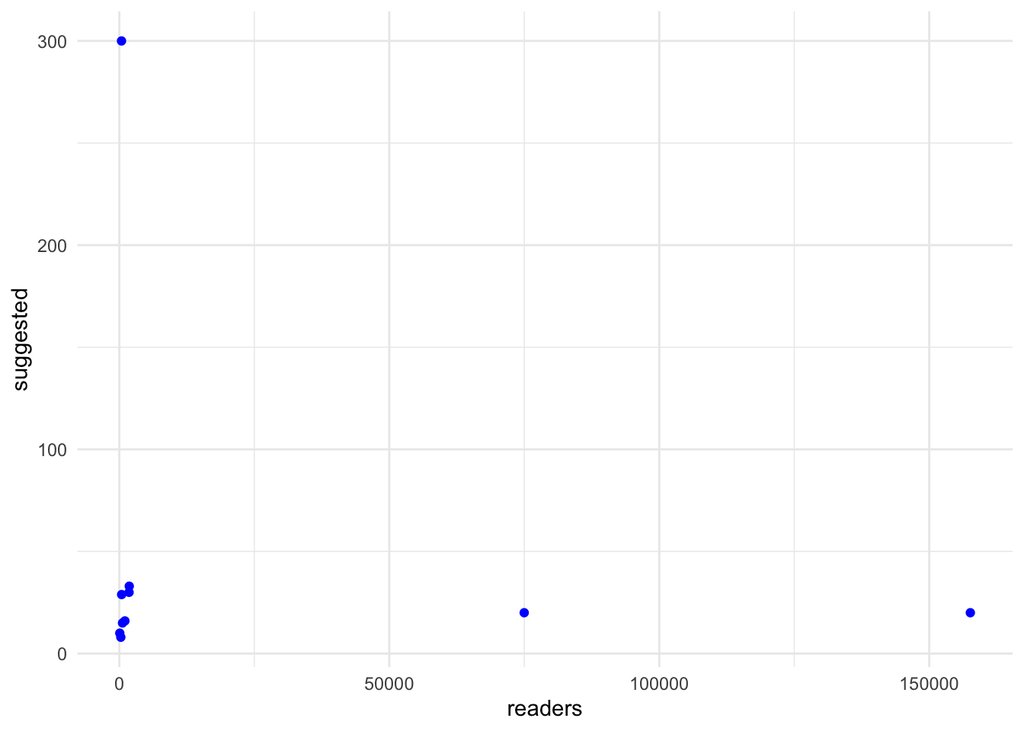

```r
ggplot(leanpub_df, aes(readers, suggested)) +
  geom_point(color = "blue") +
  theme_minimal()
```

#### Breaking it down

- **`ggplot(leanpub_df, aes(readers, suggested))`**: This sets up the plot using your dataset (`leanpub_df`).
  - `aes()`: Defines the aesthetics: what goes on the x-axis, y-axis, and how to color the bars.
- **`geom_point(color = "blue")`**: This adds blue points to the plot. One for each book in your dataset.
- **`theme_minimal()`**: This applies a clean, simple minimalist look to your plot (no extra clutter).

## Calculating the stats

Now that you’ve plotted the data, let’s take a look at the numbers!

You will want to answer the question: Is there a relationship between the number of readers a book has and its suggested price by using a correlation test? This helps us measure how closely two numeric variables move together.

*Note: We will learn more about correlation in chapter [53 In Practice Using Stats 53.4.2 How to know if your data is underpowered for your question](https://datatrail-jhu.github.io/DataTrail/in-practice-using-stats.html). The* **Breaking it down** *section can provide some helpful information about what the code is doing.*

To check if there is a relationship between readers and suggested price use this code chunk:

```r
cor.test(leanpub_df$readers, leanpub_df$suggested)
```

```
##
##  Pearson's product-moment correlation
##
## data:  leanpub_df$readers and leanpub_df$suggested
## t = -0.44803, df = 8, p-value = 0.666
## alternative hypothesis: true correlation is not equal to 0
## 95 percent confidence interval:
##  -0.7155886  0.5248777
## sample estimates:
##        cor
## -0.1564526
```

### Breaking it down

- `cor.test()`: This a function that calculates the correlation between two variables.
- `leanpub_df$readers`: Pulls the **`readers`** column from the dataset.
- `leanpub_df$suggested`: Pulls the `suggested` price column from the dataset.
- The result should include:
  - A correlation coefficient (between -1 and 1):
    - If it’s close to 1, the two variables go up together.
    - If it’s close to -1, one goes up while the other goes down.
    - If it’s close to 0, there’s no clear relationship.
  - A p-value: Tells you whether the relationship is statistically significant.

### Understanding the p-value

When running the correlation test, you’ll see a p-value:

- If the p-value is very small (generally less than 0.05), it suggests there might be a real relationship between the number of readers and the suggested price and that it’s not just due to random chance.
- It is important to keep in mind that even if the p-value is small, it doesn’t always mean that there is a strong or important relationship.
- It can mean that more data will be necessary to be certain.

If the p value reported is very very small, then there might be a relationship. But also it is likely you’ll need to collect more data to get a more confident conclusion using this test. Remember “correlation is not causation”.

## Conclusion

Write up your thoughts about this data science project here and answer the following questions:

- What did you find out about your questions?

## Printing out session info

It’s good practice to include your session info at the end of your R Markdown notebook. This provides an overview of the R environment when you used it including the version of R, the platform you’re running on, and the packages and libraries (including version numbers) that were loaded when the notebook was run.

This is helpful for:

- Reproducibility (making sure others can run your code the same way)
- Understanding what software versions were used

[session information not shown]